# Consulting Regression Application

## Instructions

1. Use regression to help you answer someone else’s question.
   - You could reach out to a friend and help them decide if they are paying a fair price for their upcoming purchase (car, computer, house, …).
   - You could reach out to someone you know that owns a small business and would be interested in your help analyzing their data.
   - You could reach out to a teacher to see if they have questions and data they are willing to share.
   - You could reach out to the Data Science Society to become a consulting statistician for one of their project teams.
   - Brother Saunders has some projects he would happy to have you work on if none of these other options pan out.
2. Your work should show the ability to perform detailed and correct statistical analysis, while summarizing the conclusions appropriately for your client “in plain English.” The main goal here is to see that you can properly interpret regression results within context in such a way that the general public can understand.

## Grading

1. Correctness of Analysis {10} Points
   - Did you use appropraite regression tools to support your final conclusions and interpretations?
2. Ability to Interpret {10} Points
   - Are your final conclusions presented in such a way that the general public can understand and apply them?

## Background

My father is looking to retire within the next few years and his mind has recently been on how to go about structuring his retirement investments. Given that I am a Financial Economics major I offered to do some preliminary research for his stock portfolio. Although the assumptions held in regression often fall apart when looking at financial data, regression is a large part of the finance world. This analysis will take a different approach to regression because while we will try to maintain normality as much as possible, the independent variables of interest are **not fixed**. Meaning that developing a causual understanding of the regressions will be extremely difficult. In this analysis I will build a model that looks at the relationship between several different stocks and Apple. This information will help my dad in building his portfolio. The stocks I will be looking in this analysis are: **AAPL**, **JBLU**, **BBY**, **GM**, and **AMZN**. I also will take a look at the **S&P 500** which tracks the performance of the overal market.

## Data

In this section I will gather my data. Thankfully, financial data is usually pretty clean. I will gather the adjusted stock data going back to 2008 and then compute its log daily returns. We eventually be regressing on AAPL Log Daily Returns (Y) against (Insert Stock Ticker Here) Log Daily Returns.

```r
stocks <- c("^GSPC", "AAPL", "JBLU", "BBY", "GM", "AMZN") %>%
  tq_get() %>%
  dplyr::select(date, symbol, adjusted) %>%
  group_by(symbol) %>%
  tq_transmute(select     = adjusted,
               mutate_fun = periodReturn,
               period     = "daily",
               type       = "log",
               col_rename = "daily.returns")
```

A quick visualization of the data shows that the returns look relatively normal. We will see how the regressions fair.

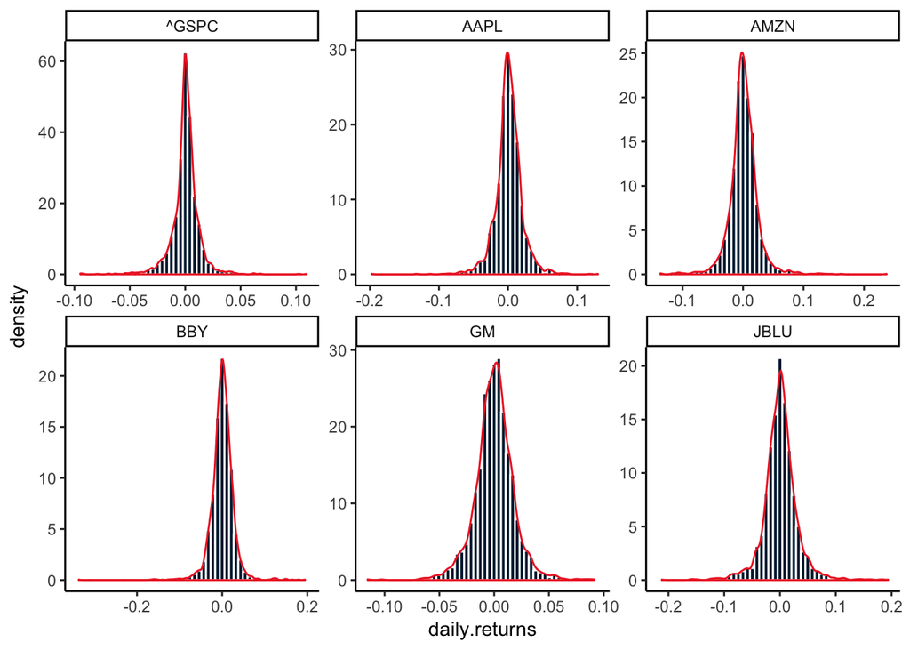

```r
stocks %>%
  ggplot(aes(x = daily.returns)) +
  geom_histogram(aes(y=..density..),color = "white", fill = "#00203b", bins = 50) +
  geom_density(aes(y=..density..), color = "firebrick2", size = .5) +
  facet_wrap(~ symbol, scales = "free") +
  theme_classic()
```

In order to correctly run the regressions we need to move our data into wide format. **Note:** GM was struggling financialy during the 2008 crisis and went private for a while, hence the missing data.

```r
stocks.wide <- stocks %>%
  spread(key = symbol, value = daily.returns) %>%
  rename(SPX = `^GSPC`)

stocks.wide %>%
  head() %>%
  pander::pander()
```

| date | SPX | AAPL | AMZN | BBY | GM | JBLU |
| --- | --- | --- | --- | --- | --- | --- |
| 2008-01-02 | 0 | 0 | 0 | 0 | NA | 0 |
| 2008-01-03 | 0 | 0.0004619 | -0.01086 | -0.03942 | NA | 0 |
| 2008-01-04 | -0.02486 | -0.07941 | -0.06981 | -0.03366 | NA | -0.02231 |
| 2008-01-07 | 0.003218 | -0.01348 | 0.0003378 | -0.007187 | NA | -0.0286 |
| 2008-01-08 | -0.01852 | -0.03663 | -0.01064 | -0.03234 | NA | -0.04147 |
| 2008-01-09 | 0.01353 | 0.04649 | -0.03074 | 0.01716 | NA | -0.03279 |

## Analysis

Lets begin by visualizing and testing AAPL vs. S&P 500. Since AAPL is apart of the S&P we should expect to see some high correlation here. Let’s take a look:

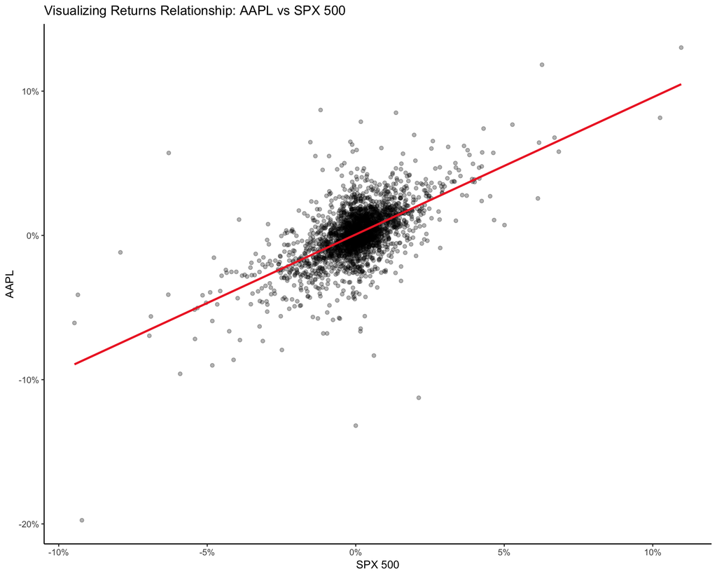

```r
aapl.spx <- lm(AAPL ~ SPX, data = stocks.wide)

stocks.wide %>%
  ggplot(aes(x = SPX, y = AAPL)) +
  geom_point(alpha = .3, size = 1.5) +
  geom_smooth(method = "lm", se = FALSE, color = "firebrick2") +
  scale_x_continuous(labels = scales::percent) +
  scale_y_continuous(labels = scales::percent) +
  labs(title = "Visualizing Returns Relationship: AAPL vs SPX 500",
       x = "SPX 500") +
  theme_classic()
```

```r
aapl.spx %>%
  summary() %>%
  pander::pander()
```

|  | Estimate | Std. Error | t value | Pr(>\|t\|) |
| --- | --- | --- | --- | --- |
| **(Intercept)** | 0.0006351 | 0.0003035 | 2.093 | 0.03646 |
| **SPX** | 0.9506 | 0.02358 | 40.31 | 4.26e-276 |

Fitting linear model: AAPL ~ SPX

| Observations | Residual Std. Error | $R^2$ | Adjusted $R^2$ |
| --- | --- | --- | --- |
| 2588 | 0.01544 | 0.3859 | 0.3856 |

This looks great but let’s attempt to verify some assumptions:

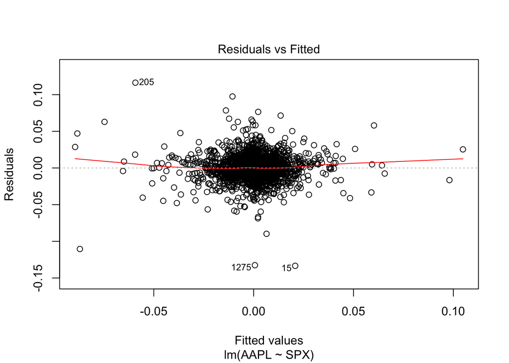

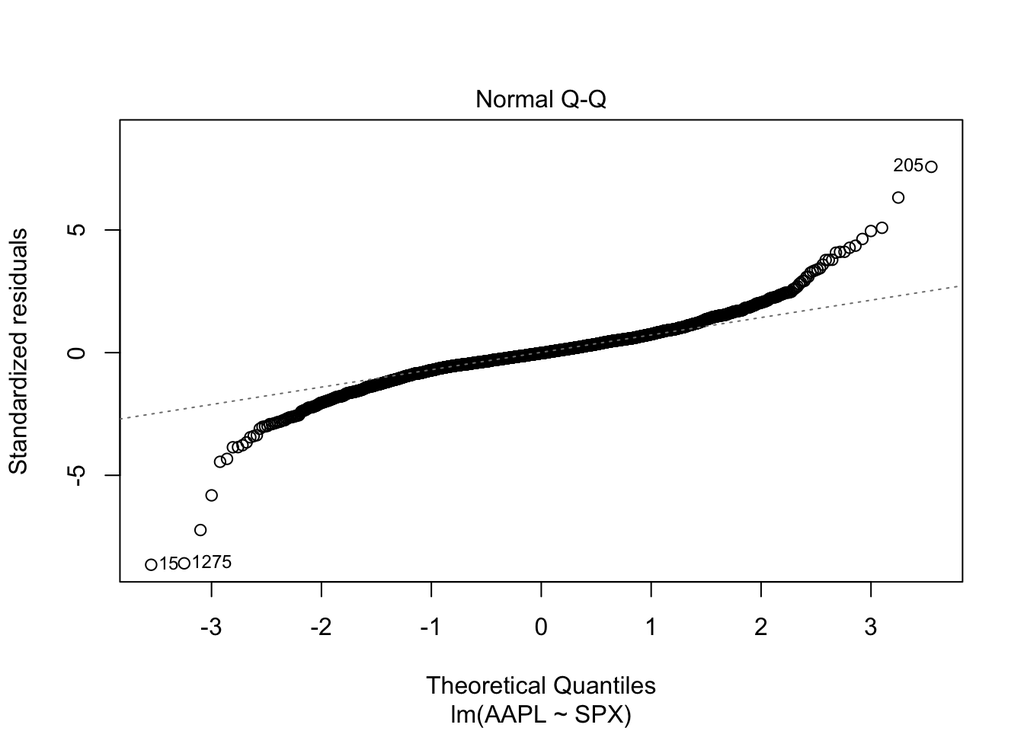

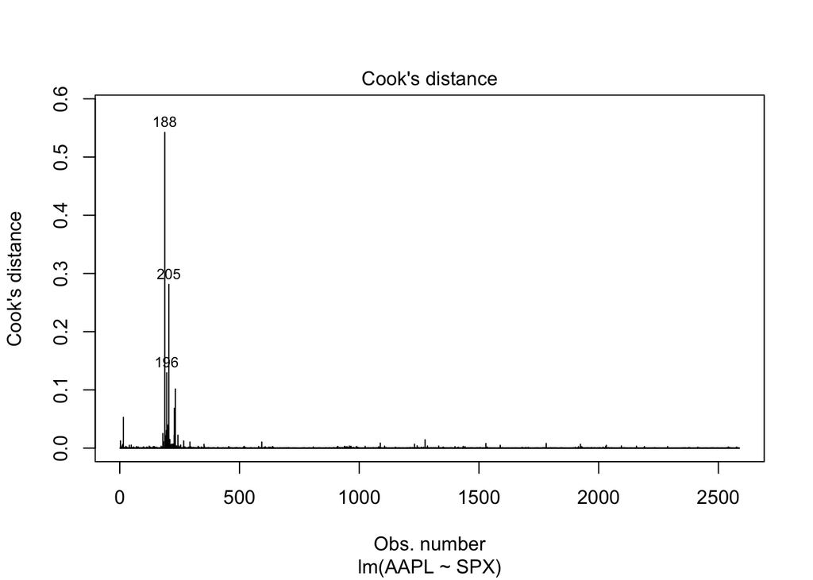

```r
plot(aapl.spx, which = c(1:2,4))
```

Linearity and variance appear to be alright and I don’t think we’ll be able to fix the non-normality of the errors. Looking at the cook’s distance there are some massive outliers which is to be expected in the stock market. Perhaps it would be best to run a robust regression to discount the weight of the outliers.

```r
aapl.spx2 <- MASS::rlm(AAPL ~ SPX, data = stocks.wide, na.action = na.omit)

summary(aapl.spx2)
```

```
##
## Call: rlm(formula = AAPL ~ SPX, data = stocks.wide, na.action = na.omit)
## Residuals:
##        Min         1Q     Median         3Q        Max
## -0.1335179 -0.0071975 -0.0002737  0.0075575  0.1167625
##
## Coefficients:
##             Value   Std. Error t value
## (Intercept)  0.0006  0.0002     2.7045
## SPX          0.9573  0.0184    51.9987
##
## Residual standard error: 0.01088 on 2586 degrees of freedom
```

Great that looks better. Let’s take a look at the other stocks:

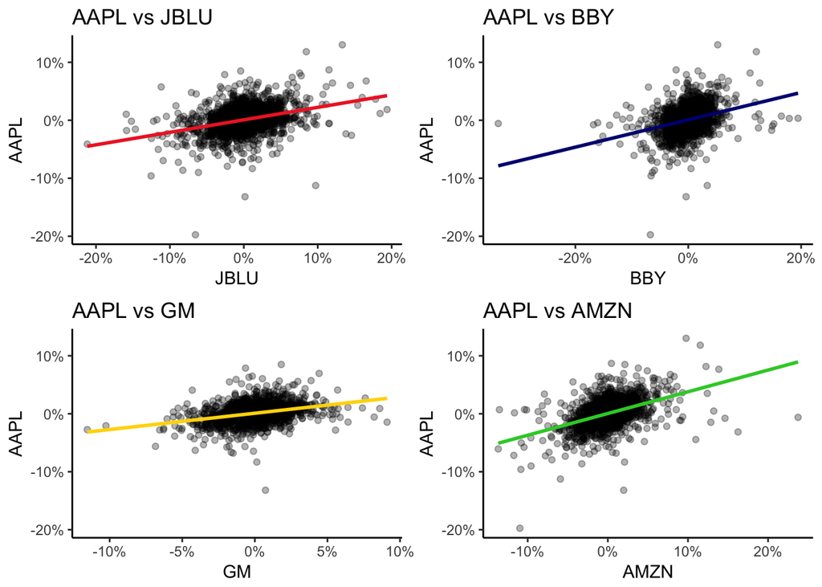

```r
jblu.plot <- stocks.wide %>%
  ggplot(aes(x = JBLU, y = AAPL)) +
  geom_point(alpha = .3, size = 1.5) +
  geom_smooth(method = "lm", se = FALSE, color = "firebrick2") +
  scale_x_continuous(labels = scales::percent) +
  scale_y_continuous(labels = scales::percent) +
  labs(title = "AAPL vs JBLU",
       x = "JBLU") +
  theme_classic()

bby.plot <- stocks.wide %>%
  ggplot(aes(x = BBY, y = AAPL)) +
  geom_point(alpha = .3, size = 1.5) +
  geom_smooth(method = "lm", se = FALSE, color = "navyblue") +
  scale_x_continuous(labels = scales::percent) +
  scale_y_continuous(labels = scales::percent) +
  labs(title = "AAPL vs BBY",
       x = "BBY") +
  theme_classic()

gm.plot <- stocks.wide %>%
  ggplot(aes(x = GM, y = AAPL)) +
  geom_point(alpha = .3, size = 1.5) +
  geom_smooth(method = "lm", se = FALSE, color = "gold") +
  scale_x_continuous(labels = scales::percent) +
  scale_y_continuous(labels = scales::percent) +
  labs(title = "AAPL vs GM",
       x = "GM") +
  theme_classic()

amzn.plot <- stocks.wide %>%
  ggplot(aes(x = AMZN, y = AAPL)) +
  geom_point(alpha = .3, size = 1.5) +
  geom_smooth(method = "lm", se = FALSE, color = "limegreen") +
  scale_x_continuous(labels = scales::percent) +
  scale_y_continuous(labels = scales::percent) +
  labs(title = "AAPL vs AMZN",
       x = "AMZN") +
  theme_classic()

jblu.plot + bby.plot + gm.plot + amzn.plot
```

Looking at these plots, some obviously look better than others. BBY has a ton of outliers is appears. AMZN looks interesting as well because it appears that it is right skewed in possible returns. This could be a good combo of stocks for my father’s portfolio. Let’s take a closer look at AAPL vs. AMZN, let’s go straight for the robust model:

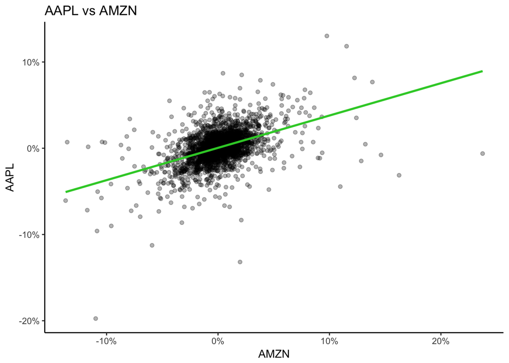

```r
stocks.wide %>%
  ggplot(aes(x = AMZN, y = AAPL)) +
  geom_point(alpha = .3, size = 1.5) +
  geom_smooth(method = "lm", se = FALSE, color = "limegreen") +
  scale_x_continuous(labels = scales::percent) +
  scale_y_continuous(labels = scales::percent) +
  labs(title = "AAPL vs AMZN",
       x = "AMZN") +
  theme_classic()
```

```r
aapl.amzn2 <- MASS::rlm(AAPL ~ AMZN, data = stocks.wide, na.action = na.omit)

summary(aapl.amzn2)
```

```
##
## Call: rlm(formula = AAPL ~ AMZN, data = stocks.wide, na.action = na.omit)
## Residuals:
##        Min         1Q     Median         3Q        Max
## -0.1532353 -0.0085315 -0.0001128  0.0087222  0.0898515
##
## Coefficients:
##             Value   Std. Error t value
## (Intercept)  0.0005  0.0003     1.8843
## AMZN         0.4078  0.0116    35.0799
##
## Residual standard error: 0.01284 on 2586 degrees of freedom
```

It would make sense that AMZN would have some predicitve power over AAPL given that they are two large companies but they do different things and in a sense are opposities from on another. AAPL works in specific market making consumer technology and while AMZN has ventured into that in recent years their scope is much larger.

## Summary

It appears that two stocks or indices to keep in mind for my father when retiring is investing with the market into the SPX and also into AMZN. My dad is an apple fanboy and these other companies could aid in understanding how AAPL might react given current market conditions.